# Human Activity Recognition: A predictive model

## Summary

The aim of this study is to generate a model for the successful prediction of the type of exercise a subject is undertaking based on measurements of their activity. The dataset used is described at the following web page:

[HAR](http://groupware.les.inf.puc-rio.br/har)

The data files are downliaded from the following links:

[training data](https://d396qusza40orc.cloudfront.net/predmachlearn/pml-training.csv) [test data](https://d396qusza40orc.cloudfront.net/predmachlearn/pml-testing.csv)

## Data loading and preparation

We begin by downloading and loading the training and test datasets before taking a look at the data structure (shown in the appendix).

```r
library(caret);library(randomForest);library(e1071)
```

```r
download.file("https://d396qusza40orc.cloudfront.net/predmachlearn/pml-training.csv", "pml-training.csv", "wget", quiet = FALSE, mode = "w",cacheOK = TRUE)
download.file("https://d396qusza40orc.cloudfront.net/predmachlearn/pml-testing.csv", "pml-testing.csv", "wget", quiet = FALSE, mode = "w",cacheOK = TRUE)
traindata<-read.csv("pml-training.csv", na.strings=c("NA","#DIV/0!",""))
testdata<-read.csv("pml-testing.csv", na.strings=c("NA","#DIV/0!",""))
```

Before constructing a predictive model we first remove features containing NA values, as well as the first seven columns of the dataset, which contain meta information, rather than features which may be included in the model. We then suset the training data into a dataset to train the model on, and a cross-validation set.

```r
traindata<-traindata[,colSums(is.na(traindata))==0]
testdata<-testdata[,colSums(is.na(testdata))==0]
traindata <- traindata[,-c(1:7)]
testdata <-testdata[,-c(1:7)]
set.seed(433)
trainindices <- createDataPartition(y=traindata$classe,p=.70,list=F)
trainTN <- traindata[trainindices,]
trainCV <- traindata[-trainindices,]
```

On plotting a bar plot for the output *classe* factor variable, we see that each kind of activity A-E has similar occurrence distribution in each of the whole training set, the subset actually used for training, and the cross-validation set.

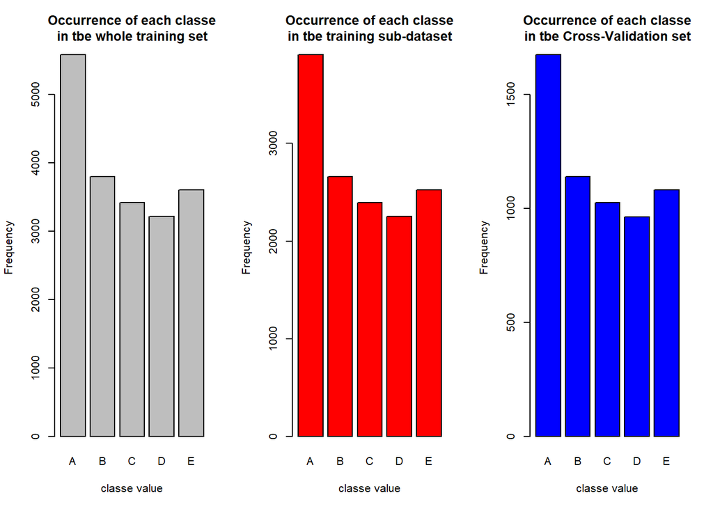

```r
par(mfrow=c(1,3))
barplot(table(traindata$classe),main="Occurrence of each classe\nin tbe whole training set",xlab="classe value",ylab="Frequency",col="grey")
barplot(table(trainTN$classe),main="Occurrence of each classe\nin tbe training sub-dataset",xlab="classe value",ylab="Frequency",col="red")
barplot(table(trainCV$classe),main="Occurrence of each classe\nin tbe Cross-Validation set",xlab="classe value",ylab="Frequency",col="blue")
```

## Model fitting: Random Forest

We first of all fit a random forest model and test it’s predictive power.

```r
randformod <- randomForest(classe ~. , data=trainTN, method="class")
randformod
```

```
##
## Call:
##  randomForest(formula = classe ~ ., data = trainTN, method = "class")
##                Type of random forest: classification
##                      Number of trees: 500
## No. of variables tried at each split: 7
##
##         OOB estimate of  error rate: 0.55%
## Confusion matrix:
##      A    B    C    D    E  class.error
## A 3905    1    0    0    0 0.0002560164
## B   13 2639    6    0    0 0.0071482318
## C    0   14 2380    2    0 0.0066777963
## D    1    0   28 2222    1 0.0133214920
## E    0    0    3    7 2515 0.0039603960
```

```r
predictCV<-predict(randformod, trainCV, type ="class")
confusionMatrix(predictCV,trainCV$classe)
```

```
## Confusion Matrix and Statistics
##
##           Reference
## Prediction    A    B    C    D    E
##          A 1670   11    0    0    0
##          B    3 1125    9    0    0
##          C    0    3 1014    5    1
##          D    0    0    3  958    3
##          E    1    0    0    1 1078
##
## Overall Statistics
##
##                Accuracy : 0.9932
##                  95% CI : (0.9908, 0.9951)
##     No Information Rate : 0.2845
##     P-Value [Acc > NIR] : < 2.2e-16
##
##                   Kappa : 0.9914
##  Mcnemar's Test P-Value : NA
##
## Statistics by Class:
##
##                      Class: A Class: B Class: C Class: D Class: E
## Sensitivity            0.9976   0.9877   0.9883   0.9938   0.9963
## Specificity            0.9974   0.9975   0.9981   0.9988   0.9996
## Pos Pred Value         0.9935   0.9894   0.9912   0.9938   0.9981
## Neg Pred Value         0.9990   0.9971   0.9975   0.9988   0.9992
## Prevalence             0.2845   0.1935   0.1743   0.1638   0.1839
## Detection Rate         0.2838   0.1912   0.1723   0.1628   0.1832
## Detection Prevalence   0.2856   0.1932   0.1738   0.1638   0.1835
## Balanced Accuracy      0.9975   0.9926   0.9932   0.9963   0.9979
```

The confusion matrix shows that the predictive accuracy of the random forest model is >99%. With such a high predictive accuracy it is considered a satisfactory predictor.

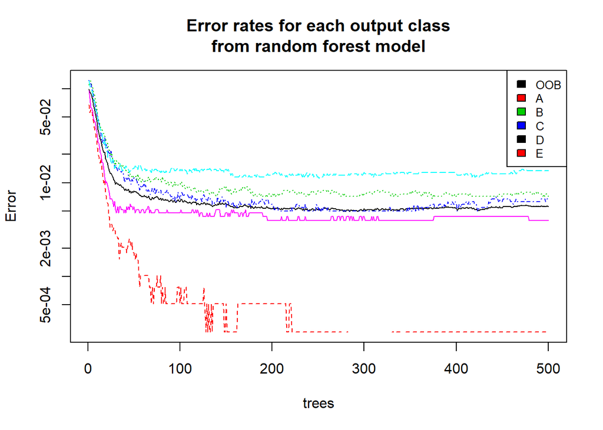

```r
plot(randformod, main="Error rates for each output class\nfrom random forest model",log="y")
legend("topright", colnames(randformod$err.rate),col=1:5,cex=0.8,fill=1:4)
```

The model is now applied to the test dataset and gives the following predictions for the test data:

```r
predicttest <- predict(randformod, testdata, type="class")
predicttest
```

```
##  1  2  3  4  5  6  7  8  9 10 11 12 13 14 15 16 17 18 19 20
##  B  A  B  A  A  E  D  B  A  A  B  C  B  A  E  E  A  B  B  B
## Levels: A B C D E
```

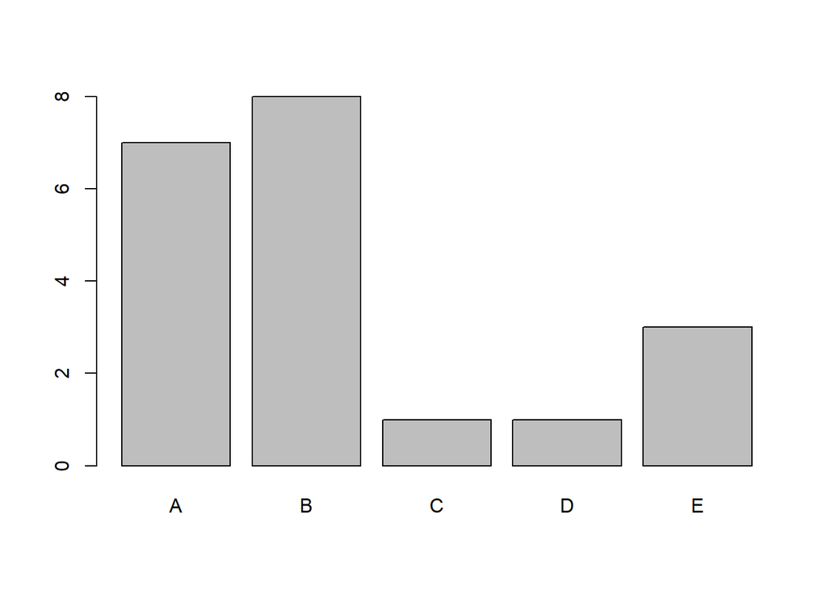

```r
barplot(table(predicttest))
```

## Appendix

The feature variable names and data structure are as follows:

```r
names(traindata)
```

```
##  [1] "roll_belt"            "pitch_belt"           "yaw_belt"
##  [4] "total_accel_belt"     "gyros_belt_x"         "gyros_belt_y"
##  [7] "gyros_belt_z"         "accel_belt_x"         "accel_belt_y"
## [10] "accel_belt_z"         "magnet_belt_x"        "magnet_belt_y"
## [13] "magnet_belt_z"        "roll_arm"             "pitch_arm"
## [16] "yaw_arm"              "total_accel_arm"      "gyros_arm_x"
## [19] "gyros_arm_y"          "gyros_arm_z"          "accel_arm_x"
## [22] "accel_arm_y"          "accel_arm_z"          "magnet_arm_x"
## [25] "magnet_arm_y"         "magnet_arm_z"         "roll_dumbbell"
## [28] "pitch_dumbbell"       "yaw_dumbbell"         "total_accel_dumbbell"
## [31] "gyros_dumbbell_x"     "gyros_dumbbell_y"     "gyros_dumbbell_z"
## [34] "accel_dumbbell_x"     "accel_dumbbell_y"     "accel_dumbbell_z"
## [37] "magnet_dumbbell_x"    "magnet_dumbbell_y"    "magnet_dumbbell_z"
## [40] "roll_forearm"         "pitch_forearm"        "yaw_forearm"
## [43] "total_accel_forearm"  "gyros_forearm_x"      "gyros_forearm_y"
## [46] "gyros_forearm_z"      "accel_forearm_x"      "accel_forearm_y"
## [49] "accel_forearm_z"      "magnet_forearm_x"     "magnet_forearm_y"
## [52] "magnet_forearm_z"     "classe"
```

```r
str(traindata)
```

```
## 'data.frame':    19622 obs. of  53 variables:
##  $ roll_belt           : num  1.41 1.41 1.42 1.48 1.48 1.45 1.42 1.42 1.43 1.45 ...
##  $ pitch_belt          : num  8.07 8.07 8.07 8.05 8.07 8.06 8.09 8.13 8.16 8.17 ...
##  $ yaw_belt            : num  -94.4 -94.4 -94.4 -94.4 -94.4 -94.4 -94.4 -94.4 -94.4 -94.4 ...
##  $ total_accel_belt    : int  3 3 3 3 3 3 3 3 3 3 ...
##  $ gyros_belt_x        : num  0 0.02 0 0.02 0.02 0.02 0.02 0.02 0.02 0.03 ...
##  $ gyros_belt_y        : num  0 0 0 0 0.02 0 0 0 0 0 ...
##  $ gyros_belt_z        : num  -0.02 -0.02 -0.02 -0.03 -0.02 -0.02 -0.02 -0.02 -0.02 0 ...
##  $ accel_belt_x        : int  -21 -22 -20 -22 -21 -21 -22 -22 -20 -21 ...
##  $ accel_belt_y        : int  4 4 5 3 2 4 3 4 2 4 ...
##  $ accel_belt_z        : int  22 22 23 21 24 21 21 21 24 22 ...
##  $ magnet_belt_x       : int  -3 -7 -2 -6 -6 0 -4 -2 1 -3 ...
##  $ magnet_belt_y       : int  599 608 600 604 600 603 599 603 602 609 ...
##  $ magnet_belt_z       : int  -313 -311 -305 -310 -302 -312 -311 -313 -312 -308 ...
##  $ roll_arm            : num  -128 -128 -128 -128 -128 -128 -128 -128 -128 -128 ...
```

[output cut: 39 more lines]